# krieg_panel3_myeloid_FCS

Yen Hoang

14 June 2018

# Re-analyze Krieg data with PRIanalyzer

## Data description

### Flow cytometry data

[output not shown]

**Note**: Out of the 14 healthy donors and the independent cohort of 31 patients with melanoma, 5 samples were excluded in each group since they were different samples.

| Panel Validation FCS |  |  |
| --- | --- | --- |
| CD11b-BV421 (ICRF44) | CD14-PE (HCD14) | HLA-DR-FITC (L243) |
| CD4-BV711 (OKT4) | CD33-BV605 (WM53) | NIR Live/dead-stain-NearInfraRed |
| CD56-Pe-Cy7 (NCAM1) | CD11c -AlexaFluor700 (B-Ly6) | CD16-APC (3G8) |
| CD45RO-ECD (2H4LDH11LD89(2H4) | CD3-BV785 | CD19-BV605 (HIB19) |

Original analysis: From the FlowJo data, the frequencies of CD3+ T cells and CD14+ CD16− HLA-DR^hi monocytes were extracted from the three groups (responders, nonresponders and healthy donors).

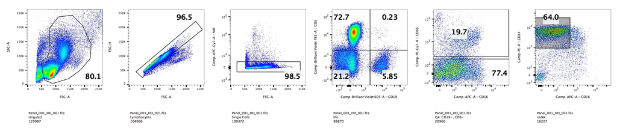

Figure 3: **Gating plan for validation FACS in original analysis.**

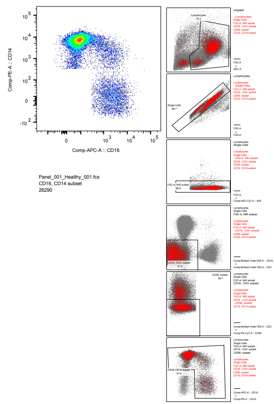

## Load validation data from database FCS

With our Upload-tool, data is already asinh-transformed with function asinh().

```r
library(RSQLite)
this=fcs
db.name = "/data/databases/YH_20180423_Myeloid_CD14CD16.sqlite3"
this$connectDb(db.name)
```

```
[1] "Database opened: /data/databases/YH_20180423_Myeloid_CD14CD16.sqlite3"
```

```r
this$total.projects=dbListTables(this$conn)
print(this$total.projects)
```

```
 [1] "DataSet01"                "DataSet01_equipmentInfo"  "DataSet01_fileIdentity"
 [4] "DataSet01_markerIdentity" "DataSet02"                "DataSet02_equipmentInfo"
 [7] "DataSet02_fileIdentity"   "DataSet02_markerIdentity" "FCS"
[10] "FCS_SPILLcolnames"        "FCS_SPILLmatrix"          "FCS_equipmentInfo"
[13] "FCS_fileIdentity"         "FCS_markerIdentity"
```

```r
### sort out metadata from database first
# index for metadata
idx=grep("markerIdentity|colnameIndex|fileIdentity|fileIndex|UserHistory|Classification|equipmentInfo|fileComments|SPILL",this$total.projects)
this$df.num = 0
for (i in idx){
  this$df.num = this$df.num + 1
  this$dataframes.name[this$df.num] = this$total.projects[i]
}
# project vector only
this$total.projects = this$total.projects[-idx]
# project: FACS
this$current.project = this$total.projects[3]
printf("Curent project: %s", this$current.project)
```

```
[1] "Curent project: FCS"
```

```r
### get indices for filenames and table
idx.table = grep(paste0("^",this$current.project,"_"),this$dataframes.name)
idx.file = grep("fileIdentity|fileIndex",this$dataframes.name)
idx.stain = grep("markerIdentity|colnameIndex",this$dataframes.name)[1]
this$fileid_name = "_fileIdentity"
this$markerid_name = "_markerIdentity"
### get filenames table
this$current.filetable = this$getDFtable(paste0(this$current.project,this$fileid_name))
this$current.filenames = this$current.filetable[,2]
### get marker names table
this$current.staintable = this$getDFtable(paste0(this$current.project,this$markerid_name))
####### load external metadata table
# file_id same in database and external table
metadata = read.csv(file=sprintf("KRIEG/Krieg_metadata_%s.csv",this$current.project))
metadata$condition = factor(metadata$condition, levels = c("HD","NR","R"))
print(summary(metadata$condition ))
```

```
HD NR  R
 9 10 11
```

```r
### specify colors for the different conditions
color_conditions = c("#2c7bb6","#f46d43","#1a9850")
names(color_conditions) = levels(metadata$condition)
```

[output not shown]

## Preprocession validation data FCS

```r
this=fcs
shortnames = sub("_CD14CD16.fcs$","",metadata$file_name)
shortnames = sub("^FCS_","",shortnames)
### long version to manipulate data and then merge
if (FALSE) {
  library(reshape2)

  data.gated.all = data.trimmed.all = data.man.all = data.frame()
  for ( i in 1:length(this$current.filenames) ) {
    #i=1

    this$selected.vars = this$getVariables(table=this$current.project,index=i)
    data.gated = this$getData(table=this$current.project,fileidx=i)

    ### Remove non-functional parameters
    idx.nonfunvar = grep("FSC|SSC|Time",colnames(data.gated))
    if (length(idx.nonfunvar)>0) data.gated = data.gated[,-idx.nonfunvar]

    ### manipulate data part #1
    file_ids = rep(this$current.filetable[i,1], nrow(data.gated))
    data.man = data.frame(file_id = file_ids, data.gated)

    ### concenate data.gated into one matrix: data.gated.all
    # generate sample IDs corresponding to each cell in the 'data' matrix
    col.fileid = rep(metadata$file_id[i],nrow(data.gated))
    data.gated = cbind(file_id=col.fileid,data.gated)
    if ( i==1 ) {
      data.gated.all = data.gated
    }  else {
      data.gated.all <- merge(data.gated.all,data.gated,all=T)
    }

    ### Save gated data
    save(data.gated, file = sprintf("KRIEG/%s_%s_gated.rda",this$current.project,shortnames[i]))

    ### trim data.gated for outliers
    data.trimmed = data.gated
    cells.removed = 0
    for (t in 1:ncol(data.trimmed)) {
      data.trimmed = data.trimmed[order(data.trimmed[,t]),]
      trim = floor(nrow(data.trimmed)*0.998)
      cells.removed = cells.removed + 2*(nrow(data.trimmed)-trim) -1
      data.trimmed = data.trimmed[(nrow(data.trimmed)-trim):trim,]
    }
    printf("Cells trimmed: -%s cells", cells.removed)

    ### Save trimmed data as rdata
    save(data.trimmed, file = sprintf("KRIEG/%s_%s_trimmed.rda",this$current.project,shortnames[i]))

    ### concenate data.trimmed into one matrix: data.trimmed.all
    if ( i==1 ) {
      data.trimmed.all = data.trimmed
    }  else {
      data.trimmed.all <- merge(data.trimmed.all,data.trimmed,all=T)
    }

    ### manipulate data part #2
    data.man = melt(data.man, id.var = "file_id", value.name = "expression", variable.name = "marker")
    #head(data.man,2)
    matchmeta = match(data.man$file_id, metadata$file_id)
    data.man$condition = metadata$condition[matchmeta]
    #head(data.man,2)
    ### Save manipulated data as rdata
    save(data.man, file = sprintf("KRIEG/%s_%s_manipulated.rda",this$current.project,shortnames[i]))

    ### concenate data.man into one matrix: data.all
    if ( i==1 ) {
      data.man.all = data.man
    }  else {
      data.man.all <- merge(data.man.all,data.man,all=T)
    }
  }
  print("Done loading, trimming and manipulating data.")
  dim(data.gated.all)
  #[1] 937849     13
  ### Save gated data as rdata
  save(data.gated.all, file = sprintf("KRIEG/%s_ALLDATA_gated.rda",this$current.project))

  dim(data.trimmed.all)
  #[1] 890233     13
  ### Save trimmed data as rdata
  save(data.trimmed.all, file = sprintf("KRIEG/%s_ALLDATA_trimmed.rda",this$current.project))

  dim(data.man.all)
  #[1] 11254188        4
  save(data.man.all, file = sprintf("KRIEG/%s_ALLDATA_manipulated.rda",this$current.project))
}
```

3. Descriptive statistics FCS

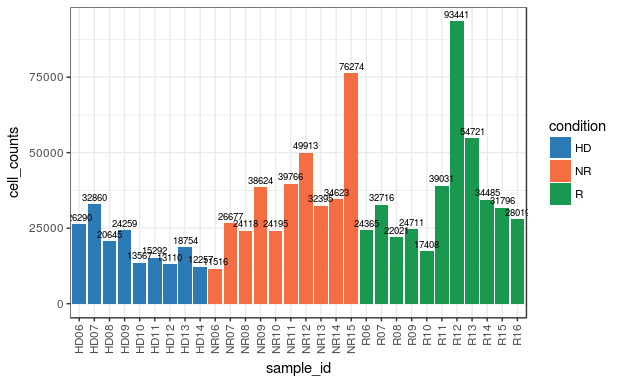

```r
library(ggplot2)
# load matrix data.all
if (TRUE) {
  load(file=sprintf("KRIEG/%s_ALLDATA_gated.rda",this$current.project))
  #dim(data.gated.all)
  #[1] 937849     13
}
cells_table = table(data.gated.all$file_id)
metadata$sample_id = sub("^base_","",metadata$sample_id)
ggdf.cellsbar = data.frame(sample_id = metadata$sample_id, cell_counts = as.numeric(cells_table) )
matchmeta = match(ggdf.cellsbar$sample_id, metadata$sample_id)
ggdf.cellsbar$condition <- metadata$condition[matchmeta]
ggplot(ggdf.cellsbar, aes(x = sample_id, y = cell_counts, fill = condition)) +
  geom_bar(stat = "identity") +
  geom_text(aes(label = cell_counts), hjust=0.5, vjust=-0.5, size = 2.5) +
  theme_bw() +
  theme(axis.text.x = element_text(angle = 90, vjust = 0.5, hjust = 1)) +
  scale_fill_manual(values = color_conditions, drop = FALSE) +
  scale_x_discrete(drop = FALSE)
```

```r
library(ggplot2)

# load matrix data.all
if (TRUE) {
  load(file=sprintf("KRIEG/%s_ALLDATA_gated.rda",this$current.project))
  #dim(data.gated.all)
  #[1] 937849     13
}

cells_table = table(data.gated.all$file_id)
metadata$sample_id = sub("^base_","",metadata$sample_id)
ggdf.cellsbar = data.frame(sample_id = metadata$sample_id, cell_counts = as.numeric(cells_table) )
matchmeta = match(ggdf.cellsbar$sample_id, metadata$sample_id)
ggdf.cellsbar$condition <- metadata$condition[matchmeta]

ggplot(ggdf.cellsbar, aes(x = sample_id, y = cell_counts, fill = condition)) +
  geom_bar(stat = "identity") +
  geom_text(aes(label = cell_counts), hjust=0.5, vjust=-0.5, size = 2.5) +
  theme_bw() +
  theme(axis.text.x = element_text(angle = 90, vjust = 0.5, hjust = 1)) +
  scale_fill_manual(values = color_conditions, drop = FALSE) +
  scale_x_discrete(drop = FALSE)
```

[output not shown]

[Figure 4: **Barplot showing the number of cells measured for each sample in the validation dataset.** Bars are colored by experimental condition: healthy donors (HD), non-responsive (NR) and responsive (R) patients. Numbers in the names on the x-axis indicate patient IDs. Numbers on top of the bars indicate the cell counts.]

### MDS plot FCS

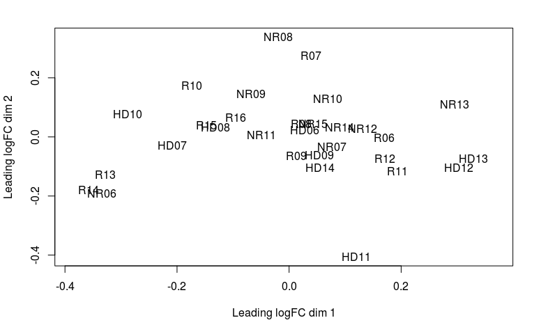

```r
this=fcs
library(dplyr)
library(limma)
# load matrix data.all
if (TRUE) {
  load(file=sprintf("KRIEG/%s_ALLDATA_manipulated.rda",this$current.project))
  #dim(data.man.all)
  #[1] 11254188        4
}
# Get the median marker expression per sample
expr_median_sample_tbl = data.man.all[,c(1,2,3)] %>% group_by(file_id,marker) %>% summarize_all(funs(median))
expr_median_sample_tbl = as.data.frame(expr_median_sample_tbl)
# and create matrix with markers in rows and samples in columns
median.mat = matrix(
  expr_median_sample_tbl[,3]
  , nrow = length(unique(expr_median_sample_tbl$marker))
  , ncol = length(metadata$sample_id)
)
colnames(median.mat) = sub("^base_","",metadata$sample_id)
rownames(median.mat) = unique(expr_median_sample_tbl$marker)
mds = plotMDS(median.mat)
```

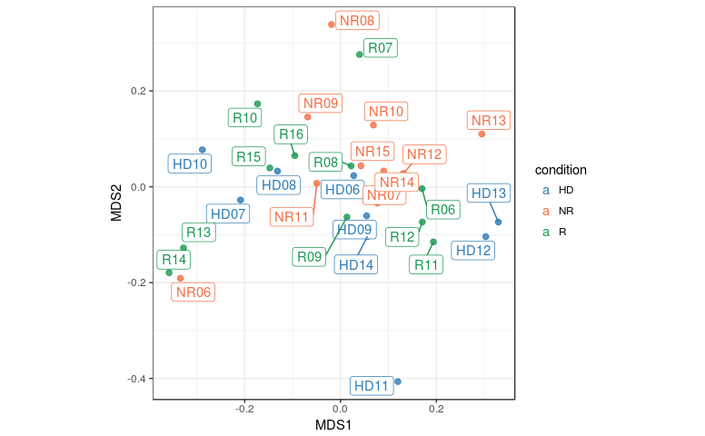

```r
ggdf.cellsbar = data.frame(sample_id = metadata$sample_id, cell_counts = as.numeric(cells_table) )
ggdf.cellsbar$condition <- metadata$condition[matchmeta]
ggdf.mds <- data.frame(MDS1 = mds$x, MDS2 = mds$y,
  sample_id = colnames(median.mat))
matchmeta = match(ggdf.mds$sample_id, metadata$sample_id)
ggdf.mds$condition <- metadata$condition[matchmeta]
library(ggrepel)
ggplot(ggdf.mds, aes(x = MDS1, y = MDS2, color = condition)) +
  geom_point(size = 2, alpha = 0.8) +
  geom_label_repel(aes(label = sample_id)) +
  theme_bw() +
  scale_color_manual(values = color_conditions) +
  coord_fixed()
```

[Figure 5. **MDS plot for the three conditions: 9 healthy donors, 10 non-responsive and 11 responsive patients.** Calculations are based on the median of the asinh-transformed marker expression of 12 lineage markers across all cells measured for each sample. Distances between samples in the plot approximate the typical change in medians. Numbers in the label names indicate patient IDs.]

### Heatmap + Dendrogram FCS

```r
library(RColorBrewer)
library(pheatmap)

matchmeta = match(ggdf.cellsbar$sample_id, metadata$sample_id)
annotation_col <- data.frame(
  condition = metadata$condition[matchmeta],
  row.names = colnames(median.mat)
)
annotation_colors <- list(condition = color_conditions)
# Colors for the heatmap
color <- colorRampPalette(brewer.pal(n = 9, name = "YlGnBu"))(100)
pheatmap(median.mat, color = color, display_numbers = TRUE,
  number_color = "black", fontsize_number = 5, annotation_col = annotation_col,
  annotation_colors = annotation_colors, clustering_method = "average")
```

[output not shown]

### Marker ranking based on the non-redundancy score (NRS) FCS

In this step, we identify the ability of markers to explain the variance observed in each sample. In particular, we calculate the PCA-based non-redundancy score (NRS) (Levine et al., 2015). Markers with higher score explain a larger portion of variability present in a given sample.

The average NRS can be used to select a subset of markers that are non-redundant in each sample but at the same time capture the overall diversity between samples. Such a subset of markers can be then used for cell population identification analysis (i.e. clustering). We note that there is no precise rule on how to choose the right cutoff for marker inclusion, but one of the approaches is to select a suitable number of the top-scoring markers. The number can be chosen by analyzing the plot with the NR scores (see Figure 7), where the markers are sorted by the decreasing average NRS. Based on the prior biological knowledge, one can refine the marker selection and drop out markers that are not likely to distinguish cell populations of interest, even if they have high scores, and add in markers with low scores but known to be important in discerning cell subgroups (Levine et al., 2015). Thus, the NRS analysis serves more as a guide to marker selection and is not meant as a hardcoded rule.

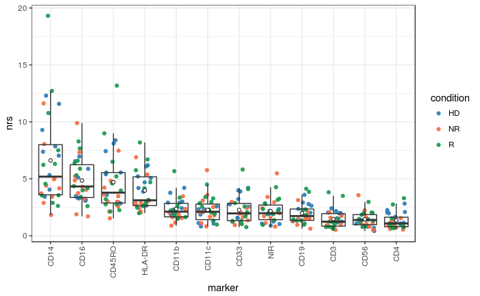

```r
library(reshape2)
### short version to load exprs data and then merge
load(file=sprintf("KRIEG/%s_ALLDATA_gated.rda",this$current.project))
#dim(data.gated.all)
#[1] 937849     13
## Define a function that calculates the NRS per sample
NRS <- function(x, ncomp = 3){
  pr <- prcomp(x, center = TRUE, scale. = FALSE)
  score <- rowSums(outer(rep(1, ncol(x)),
  pr$sdev[1:ncomp]^2) * abs(pr$rotation[,1:ncomp]))

  return(score)
}
## Calculate the score
data.NRS = list()
for ( i in 1:length(metadata$file_id) ) {
  data.tmp = data.gated.all[which(data.gated.all[,1]==metadata$file_id[i]),(2:ncol(data.gated.all))]
  data.NRS[[i]] = NRS(data.tmp)
}
data.nrs = t(as.data.frame((data.NRS)))
rownames(data.nrs) = metadata$sample_id
nrs.mean = colMeans(data.nrs)
## Plot the NRS for ordered markers
nrs.sorted <- names(sort(nrs.mean, decreasing = TRUE))
data.nrs=data.frame(data.nrs)
data.nrs$sample_id = rownames(data.nrs)
colnames(data.nrs) = c(colnames(data.tmp),"sample_id")
ggdf.nrs = melt(data.nrs, id.var = "sample_id",
                value.name = "nrs", variable.name = "marker")
ggdf.nrs$marker = factor(ggdf.nrs$marker, levels=nrs.sorted)
matchmeta = match(ggdf.nrs$sample_id, metadata$sample_id)
ggdf.nrs$condition <- metadata$condition[matchmeta]
ggplot(ggdf.nrs, aes(x = marker, y = nrs)) +
  geom_point(aes(color = condition), alpha = 0.9,
             position = position_jitter(width = 0.3, height = 0)) +
  geom_boxplot(outlier.color = NA, fill = NA) +
  stat_summary(fun.y = "mean", geom = "point", shape = 21, fill = "white") +
  theme_bw() +
  theme(axis.text.x = element_text(angle = 90, vjust = 0.5, hjust = 1)) +
  scale_color_manual(values = color_conditions)
```

[Figure 7. **Non-redundancy scores for each of the 12 differential markers and all samples in the myeloid dataset.** The full points represent the per-sample NR scores (colored by experimental conditions), while empty black circles indicate the mean NR scores from all the samples. Markers on the x-axis are sorted according to the decreasing average NRS.]